# Metagenome Quality Control and Normalization

Published

18 Sep 2026

## Overview:

#### Quality Control and Normalization

1. **Step 1: Load data and meta data**  
   Load data and meta data and filter out any QC samples.
2. **Step 2: Filter low count samples**  
   Inspect quality control samples by plotting
3. **Step 3: Taxonomical-filtering**  
   Identify treshold for low abundant taxa to filter
   1. Split clade name into seperate columns
   2. Identify the strains to remove
   3. Aggregate removed strains by higher levels
   4. Get longer format and add back clade_names
   5. Subtract filtered taxa from each higher taxa levels
   6. Check for samples with total taxa < 60% after filtering
   7. Check and replace negative values with zero
   8. Re-normalize each sample to 100%
4. **Step 4: Simplify clade names**
5. **Step 5: Plot barplots**
6. **Step 6: Centered Log Ratio (CLR) Transformation**
7. **Step 7: Exploratory Unsupervised PCA**
8. **Step 8: Exploratory Heatmap**

### Load Libraries

```r
##################
# LOAD LIBRARIES #
##################
library(tidyverse)
library(mixOmics)
library(readxl)
library(cowplot)
library(RColorBrewer)
library(scales)
library(kableExtra)
select <- dplyr::select
map <- purrr::map

#################
# COLOUR PALLET #
#################
# colour pallets
pal <- list(
  CST = c(
    "I" = "#148F77",
    "II" = "#6d9f06",
    "III" = "#A3E4D7",
    "IV-B" = "#E794C1",
    "IV-C" = "#b5cb8c",
    "V" = "#43BA8F"
  ),
  subCST = c(
    "#a5c97b",
    "#cc93cf",
    "#de9548",
    "#63d3b4",
    "#9e8dec",
    "#902267",
    '#FB5273',
    "#91c5de"
  ),
  "Fungal culture: C. albicans (y/n)" = c("#EAEAEA", "#fd814e"),
  RVVC = c("#EAEAEA", "#fd814e"),
  BV = c("#EAEAEA", "#fd814e"),
  NAC = c("#EAEAEA", "#fd814e"),
  ST = c("#EAEAEA", "#fd814e"),
  missing_page = c("#EAEAEA", "#fd814e"),
  Clin = c("#a5c97b", "#cc93cf", "#de9548", "#63d3b4", "#9e8dec", "#902267"),
  Clin_gr = c("#ffa998", '#FB5273', "#902267"),
  RVVC_AS = c("#ffa998", '#FB5273', "#902267"),
  RVVC_pos = set_names(
    c(
      "#A6CEE3",
      "#1F78B4",
      "#e490c4ff",
      "#c12d88ff"
    ),
    c("Control_neg", "Control_pos", "RVVC_neg", "RVVC_pos")
  ),
  # "#FB9A99", "#E31A1C", "#B2DF8A", "#609c5bff", "#FDBF6F", "#FF7F00",, "#CAB2D6", "#6a3d9a" "#e490c4ff", "#c12d88ff"
  trx_louvain_7 = c(
    "#de9548",
    "#cc93cf",
    "#a5c97b",
    "#9e8dec",
    "#902267",
    "#63d3b4",
    '#FB5273'
  ),
  trx_louvain_6 = c(
    "#cc93cf",
    "#de9548",
    "#a5c97b",
    "#9e8dec",
    "#902267",
    "#63d3b4",
    '#FB5273'
  ),
  metab_louvain = c(
    "#cc93cf",
    "#a5c97b",
    "#de9548",
    "#902267",
    "#9e8dec",
    "#63d3b4",
    '#FB5273'
  ),
  microb_louvain = c(
    "#cc93cf",
    "#de9548",
    "#a5c97b",
    "#9e8dec",
    "#902267",
    "#63d3b4",
    '#FB5273'
  ),
  fun_louvain = c(
    "#a5c97b",
    "#cc93cf",
    "#de9548",
    "#63d3b4",
    "#9e8dec",
    "#902267",
    '#FB5273'
    #"#984EA3"
    #"#B3CDE3"
  ),
  integ_louvain = c(
    "#a5c97b",
    "#cc93cf",
    "#de9548",
    "#63d3b4",
    "#9e8dec",
    "#902267",
    '#FB5273',
    "#984EA3"
    #"#B3CDE3"
  ),
  "Wet_smear:_clue_cells_(y/n)" = c("#2266ac", "#91c5de"),
  hyphae = c("#f26386", "#fd814e", "#a4d984", "#fbbc52"),
  pos = c("#91c5de", "#2266ac"),
  fct6_clus = c("#F8766D", "#7CAE00", "#00BFC4", "#C77CFF"),
  fct1_clus = c("#33A02C", "#B2DF8A", "#FF7F00", "#FDBF6F"), #"#FDBF6F" "#FF7F00", "#CAB2D6", "#6A3D9A"
  "Clinical score (0-5)" = brewer.pal(6, name = "Reds"),
  "Clinical_score_(0-5)" = brewer.pal(6, name = "Reds")
)

pal1 <- c("#902267", "#ffa998", "#f588af", "gray") # "gray", #e05e85
pal2 <- c(
  "#f26386",
  "#f588af",
  "#a4d984",
  "#5f983cff",
  "#fbbc52",
  "#fd814e",
  "gray"
)
RVVC_pal <- c("#A6CEE3", "#1F78B4", "#e490c4ff", "#c12d88ff")

gg_color_hue <- function(n) {
  hues <- seq(15, 375, length = n + 1)
  hcl(h = hues, l = 65, c = 100)[1:n]
}

# setwd("/Users/vilkal/work/Brolidens_work/Projects/Candida-omics/src")

taxonomy <- c(
  "kingdom",
  "phylum",
  "class",
  "order",
  "family",
  "genus",
  "species",
  "strain"
)
```

The first part of this script follows the preprocessing steps outlined on the MixOmics tutorial https://mixomics.org/mixmc/mixmc-preprocessing/

## Step 1: Load data

```r
data_path <- "/Users/vilkal/work/Brolidens_work/Projects/Candida-omics/Tidy_data/Metagenomics/Metageonome_all_vagswab_metaphlan.csv"
count_info_vagswab_path <- "../Tidy_data/Metagenomics/Read_count_info_vaginalswab.csv"
meta_path <- "/Users/vilkal/Downloads/Metadata_svamp.xlsx"
meta_path <- "/Users/vilkal/work/Brolidens_work/Projects/Candida-omics/data/Metadata_svamp_FINAL.xlsx"

#############
# LOAD DATA #
#############
data <- read_csv(data_path)
count_info_vagswab <- read_csv(count_info_vagswab_path)
meta_data <- read_xlsx(meta_path, sheet = "Metadata", skip = 1, na = "na")
meta_data <- read_xlsx(meta_path, sheet = "Metadata", skip = 0, na = "na")

comb_meta_path <- "../Results/Combined_gr_meta_data_all.csv"
meta_gr <- read_csv(comb_meta_path) %>%
  rename(sample = "svamp_ID") %>%
  mutate(across(2:25, ~ factor(.x)))
```

```r
g <- c(
  "0" = "0-1",
  "1" = "0-1",
  "2" = "2-3",
  "3" = "2-3",
  "4" = "4-5",
  "5" = "4-5"
)

gr_data <- meta_data %>%
  rename(
    `Symptom score (0-5)` = "Symptom score (0-5) - ibland har de svarat olika skriftligt i frågeformuläret och muntligt vid inklusiion, då har jag valt den högsta scoren"
  ) %>%
  select(
    svamp_ID,
    `Clinical score (0-5)`,
    `Fungal culture: C. albicans (y/n)`,
    `Fungal culture: Non-albicans candida spp. (y/n)`,
    `Symptom score (0-5)`,
    `Recurring fungal infections > 2/year (y/n)`
  ) %>%
  mutate(
    group = case_when(
      `Fungal culture: C. albicans (y/n)` == "1" &
        `Symptom score (0-5)` >= 1 &
        `Recurring fungal infections > 2/year (y/n)` == "1" ~
        "RVVCpos",

      `Fungal culture: C. albicans (y/n)` == "0" &
        `Recurring fungal infections > 2/year (y/n)` == "1" ~
        "RVVCneg",

      `Fungal culture: C. albicans (y/n)` == "1" &
        `Symptom score (0-5)` == 0 ~
        "AS",

      `Fungal culture: C. albicans (y/n)` == "0" &
        `Recurring fungal infections > 2/year (y/n)` == "0" ~
        "Control",

      `Fungal culture: C. albicans (y/n)` == "1" &
        `Recurring fungal infections > 2/year (y/n)` == "0" ~
        "Candidapos",

      TRUE ~ NA_character_
    )
  ) %>%
  mutate(
    pos = case_when(
      `Fungal culture: C. albicans (y/n)` == "1" |
        `Fungal culture: Non-albicans candida spp. (y/n)` == 1 ~
        "pos",
      TRUE ~ "neg"
    ),
    .after = "group"
  ) %>%
  mutate(
    Clin_gr = g[as.character(.$`Clinical score (0-5)`)],
    .after = "group"
  ) %>%
  select("svamp_ID", group, everything())
```

## Step 2: Filter low count samples

```r
# Identify samples with low total reads < 20 million total reads (human + bacterial)
count_info_vagswab %>%
  filter(after_fastp < 20000000) %>% # 1 sample
  knitr::kable()
```

| Sample | barcode_shotgun_swab | DS_ID | svamp_ID | ID | duplication | before_fastp | after_fastp | after_kraken2_host_removal | CST | subCST |
| --- | --- | --- | --- | --- | --- | --- | --- | --- | --- | --- |
| 242_MiKantarell__FF06581440__E200019430_L1_72_ | FF06581440 | K10 | S10 | S10 | 0.0004724 | 12701 | 12691 | 10805 | NA | NA |

```r
# check bacterial reads bellow 100k
count_info_vagswab %>%
  filter(after_kraken2_host_removal < 100000) %>%
  knitr::kable()
```

| Sample | barcode_shotgun_swab | DS_ID | svamp_ID | ID | duplication | before_fastp | after_fastp | after_kraken2_host_removal | CST | subCST |
| --- | --- | --- | --- | --- | --- | --- | --- | --- | --- | --- |
| 242_MiKantarell__FF06581440__E200019430_L1_72_ | FF06581440 | K10 | S10 | S10 | 0.0004724 | 12701 | 12691 | 10805 | NA | NA |

```r
# remove samples with low read count
data <- data %>%
  select(-S10) # removes ctrl and extra samples
```

## Plot control samples

```r
#colors
#colors
group.colors <- c(
  "Alicyclobacillus acidiphilus" = "#FB5273",
  "Lactobacillus crispatus" = "#148F77",
  "Lactobacillus iners" = "#A3E4D7",
  "Lactobacillus gasseri" = "#6D9F06",
  "Lactobacillus jensenii" = "#4E7705",
  "Lactobacillus acidophilus" = "#b4cb8c",
  "Gardnerella vaginalis" = "#CC79A7", #"#7D3560",
  "Fannyhessea vaginae" = "#EFB6D6", #"#E794C1",
  "Streptococcus agalactiae" = "#FFD5AF",
  "Limosilactobacillus portuensis" = "#F09163",
  "Candida albicans" = "#8B0000",
  "Ureaplasma parvum" = "#ff7f00",
  "other" = "#8B8B8B",

  "Sneathia vaginalis" = "#7786e9",

  "Coriobacteriales bacterium DNF00809" = "#afb7ee",
  "GGB3012 SGB4003" = "#8892d5",

  "Staphylococcus aureus" = "#566be9",
  "Prevotella bivia" = "#fecf44",
  "Prevotella amnii" = "#dcb12e",
  "Dialister micraerophilus" = "#ffe2c9",
  "Aerococcus christensenii" = "#A569BD",
  "Megasphaera lornae" = "#C17754"
)
pal_list <- list(
  Alicyclobacillus = c("#FB5273"),
  Lactobacillus = c(
    "#148F77",
    "#A3E4D7",
    "#6D9F06",
    "#4E7705",
    "#b4cb8c",
    "#6e9b20",
    "#6ba705",
    "#50701a"
  ),
  Gardnerella = c(
    "#8a3c4eff",
    "#cc79a7",
    "#d45265ff",
    "#f07487ff",
    "#f1a6b1",
    "#f5b4be",
    "#f9d1d7"
  ),
  Fannyhessea = c("#EFB6D6", "#E794C1"),
  Prevotella = colorRampPalette(colors = c("#e06806ff", "#eebc89ff"))(24),
  # Prevotella = c(
  #   "#e06806ff",
  #   "#e2771fff",
  #   "#e99a59ff",
  #   "#f0c497ff",
  #   "#eebc89ff"
  # ),
  Candida = c("#8B0000", "#c61717", "#d84141", "#ef7575"),
  Megasphaera = c("#C17754", "#c7927a"),
  Sneathia = c("#5b97e4", "#77bbe9"),
  Aerococcus = c("#b1436d"),
  Limosilactobacillus = colorRampPalette(colors = c("#A569BD", "#d3b1e1"))(5),
  Coriobacteriales = c("#afb7ee"),

  Staphylococcus = c("#566be9", "#909ff5", "#b9c3f8"),
  Alloscardovia = c("#d84eac", "#e69fdf"),

  Streptococcus = colorRampPalette(colors = c("#f9f034", "#f5f2b0"))(14), #c("#fecf44", "#fac526", "#dcb12e") c("#FFD5AF"),
  Dialister = c("#ffbb96", "#ffe2c9"),
  Ureaplasma = c("#ff7f00", "#fead5b"),
  Lacticaseibacillus = c("#8892d5", "#afb7ea"),
  Bifidobacterium = colorRampPalette(colors = c("#59a14f", "#b5ebaeff"))(4),

  #Veillonellaceae = c(),
  #"GGB3012 SGB4003" = ,
  GGB = c("#fecf44", "#fac526", "#ebbb2c", "#cda839"), #c("#59a14f", "#77a371ff", "#71a38cff", "#9cd694ff", "#b5ebaeff"),
  #other = c("gray")
  other = c(
    "#E3E6AD",
    "#F8D0A4",
    "#c4ce96",
    "#9aacce",
    "#e1caff",
    "#abc5bf",
    "#ffffd4",
    "#c0a2c1",
    "#c8ffd5",
    "#c8ffd5",
    "#afb7ee",
    "#ffc8d9",
    "#ffc8d9",
    "#e7b993",
    "#c8ffd5",
    "#c4cea9",
    "#a1b37d",
    "#a6cca7",
    "#d1b9ee",
    "#88c29c",
    "#fdcc8a",
    "#91c6f7",
    "#f5f8bd",
    "#8db1c5",
    "#fab0aa",
    "#7cb6b6",
    "#96f3eb",
    "#6ececc"
  )
)

taxa_col.fun <- function(df) {
  lvls <- names(pal_list)
  gr_lvls <- lvls %>% paste0(., collapse = "|")
  d <- df %>%
    mutate(
      gr_lvl = ifelse(
        str_detect(feature, gr_lvls),
        str_extract(feature, gr_lvls),
        "other"
      )
    ) %>%
    group_by(gr_lvl) %>%
    arrange(desc(abundance)) %>%
    select(gr_lvl, feature) %>%
    ungroup() %>%
    unique() %>%
    mutate(gr_lvl = factor(.$gr_lvl, levels = lvls)) %>%
    arrange(gr_lvl) %>%
    nest(.by = "gr_lvl") %>%
    mutate(
      data = map2(
        gr_lvl,
        data,
        ~ if (.x == "other") arrange(.y, as.character(feature)) else .y
      )
    ) %>%
    unnest(cols = c(data))

  col <- d %>%
    group_by(gr_lvl) %>%
    #mutate(col = list(pal_list[[cur_group_id()]])) %>%
    mutate(col = pal_list[[first(gr_lvl)]][seq_len(n())]) %>%
    ungroup() %>%
    select(-gr_lvl) %>%
    deframe()

  return(col)
}
```

```r
############################
# GET CTRL SAMPLES #
###########################
t <- set_names(taxonomy, seq_along(taxonomy))
data_ctrl <- data %>%
  select(
    clade_name,
    contains("ex"),
    contains("seq"),
    contains("_run2"),
    starts_with("KX")
  ) %>% # removes ctrl and extra samples
  select(-matches("_1W|_3M|_6M")) %>%
  mutate(
    level = factor(
      t[as.character(str_count(clade_name, "\\|") + 1)],
      levels = taxonomy
    ),
    .after = "clade_name"
  ) # %>%
# separate(
#   col = clade_name,
#   into = taxonomy,
#   sep = "\\|",
#   remove = FALSE,
#   fill = "right"
# )

# Modify taxa labels
data_ctrl <- data_ctrl %>%
  mutate(
    taxa = str_extract_all(
      clade_name,
      "(?<=k__|p__|c__|o__|f__|g__|s__|t__)[^|]+"
    ),
    taxa = map2_chr(
      taxa,
      level,
      ~ {
        if (.y %in% c("species", "strain")) {
          # keep everything from genus onward
          start <- which(
            c("k", "p", "c", "o", "f", "g", "s", "t") %in% substr(.y, 1, 1)
          )
          paste(.x[start:length(.x)], collapse = " ")
        } else {
          # keep only the last element (current level)
          tail(.x, 1)
        }
      }
    ),
    .after = "level"
  ) %>%
  select(-clade_name) %>%
  rename(clade_name = taxa)

# pivot longer and calculate perecentage for the 15 most abundant taxa
df_ctrl_long <- data_ctrl %>%
  # select taxonomy level
  filter(grepl("strain", level)) %>%
  # remove long strain id, replace with int:
  # mutate(
  #   clade_name = make.unique(sub("\\s+\\S+$", "", clade_name), sep = " ")
  # ) %>%
  # mutate(strain = clade_name, .after = "level") %>%
  # replace "_" with " ":
  mutate(clade_name = str_replace_all(clade_name, "\\||_", " ")) %>%
  mutate(clade_name = str_replace(clade_name, " \\d", "")) %>%
  # removes taxa that sums to zero:
  filter(sum(c_across(where(is.double))) != 0) %>%
  # arrange acording to taxa rowsum
  arrange(desc(rowSums(across(where(is.numeric))))) %>%
  {
    . ->> top_taxa
  } %>%
  # mutate(clade_name = factor(.$clade_name, levels = .$clade_name)) %>%
  # slice_head(., n = 15) %>%
  pivot_longer(
    cols = where(is.double),
    names_to = "sample",
    values_to = "abundance"
  ) %>%
  # get genus-strain lvl columns:
  mutate(genus = str_extract(clade_name, "^\\w+"), .before = "sample") %>%
  mutate(
    species = str_replace(clade_name, " \\w+$", ""),
    .before = "sample"
  ) %>%
  mutate(
    strain = make.unique(sub("\\s+\\S+$", "", clade_name), sep = " "),
    .by = "sample",
    .before = "sample"
  )


#####################
# GET COLOUR PALLET #
#####################
# top taxa
# use this information to build a pallet for the 20 top abundant genus:
top_taxa <- df_ctrl_long %>%
  summarise(sum = sum(abundance), .by = c("genus", "species", "strain")) %>%
  arrange(desc(sum)) %>%
  # get right order of legend
  mutate(species = factor(.$species, levels = unique(.$species))) %>%
  mutate(genus = factor(.$genus, levels = unique(.$genus))) %>%
  arrange(genus, species, strain) %>%
  {
    . ->> top
  } %>%
  nest(., .by = "genus") %>%
  .[1:20, ]

# top 20 genus colour pallet
MG_colours <- df_ctrl_long %>%
  # Non-abundant taxa to "other":
  mutate(feature = strain) %>%
  mutate(
    feature = ifelse(
      grepl(paste0(top_taxa$genus, collapse = "|"), .$strain),
      .$strain,
      "other"
    )
  ) %>%
  # gets colour for each taxa
  taxa_col.fun(.)

# save pallet for later use
top %>%
  mutate(
    col = ifelse(strain %in% names(MG_colours), MG_colours[.$strain], "gray")
  ) #%>%
```

```
# A tibble: 244 × 5
   genus            species                      strain                sum col
   <fct>            <fct>                        <chr>               <dbl> <chr>
 1 Alicyclobacillus Alicyclobacillus acidiphilus Alicyclobacillus … 500.   #FB5…
 2 Gardnerella      Gardnerella vaginalis        Gardnerella vagin… 215.   #8a3…
 3 Gardnerella      Gardnerella vaginalis        Gardnerella vagin…  24.2  #cc7…
 4 Gardnerella      Gardnerella vaginalis        Gardnerella vagin…   2.96 #d45…
 5 Gardnerella      Gardnerella vaginalis        Gardnerella vagin…   0    #f07…
 6 Gardnerella      Gardnerella vaginalis        Gardnerella vagin…   0    #f1a…
 7 Gardnerella      Gardnerella vaginalis        Gardnerella vagin…   0    #f5b…
 8 Gardnerella      Gardnerella vaginalis        Gardnerella vagin…   0    #f9d…
 9 Lactobacillus    Lactobacillus crispatus      Lactobacillus cri… 179.   #A3E…
10 Lactobacillus    Lactobacillus iners          Lactobacillus ine… 149.   #148…
# ℹ 234 more rows
```

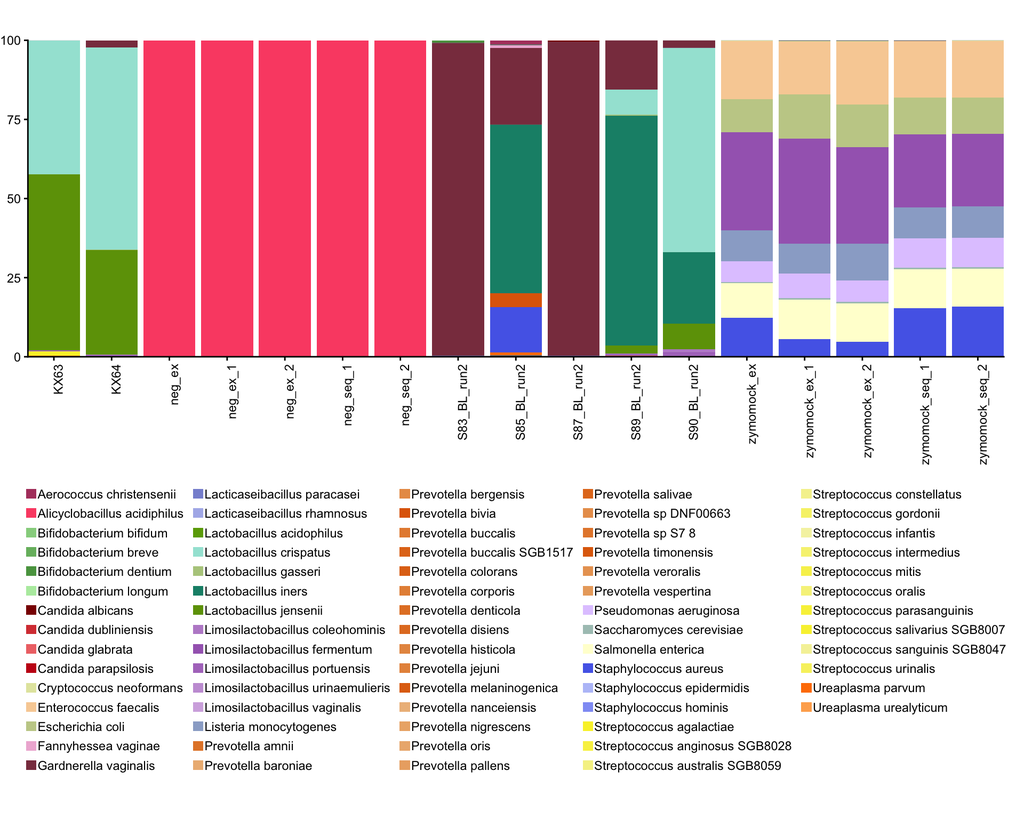

```r
#write_csv(., "../Results/Metagenomics/Metagenome_col_pal.csv")

# Select top 20 species
# you can choose if you want to include species by sum abundance or by alfabetical
# dpending on if you use the levels() or just the order of n
n <- levels(top$species)
n_lvl <- top$species %>% unique() %>% as.vector()

#plot the ctrls
# quartz(width = 10, height = 8, dpi = 120)
barplot <- df_ctrl_long %>%
  #mutate(species = factor(species, levels = n)) %>%
  ggplot(
    .,
    aes(x = sample, y = abundance, fill = species) # round(value, digits = 3)
  ) +
  geom_col(width = .9, position = "stack") +
  # geom_text(aes(label = value), position = position_stack(vjust = 0.5)) +
  scale_fill_manual(values = MG_colours) + # pal[1:colourCount]
  guides(
    fill = guide_legend(
      override.aes = list(size = 2),
      ncol = 5,
      byrow = FALSE,
      keyheight = .4,
      keywidth = .6
    )
  ) +
  theme_classic() +
  coord_cartesian(expand = F) +
  theme(
    plot.margin = unit(c(1, 0.5, 1, 0), "cm"),
    legend.spacing.y = unit(.5, 'cm'),
    legend.title = element_blank(),
    legend.text = element_text(margin = margin(r = .3, l = .3, unit = "pt"), ),
    axis.title = element_blank(),
    axis.text.x = element_text(angle = 90, hjust = 1),
    legend.position = "bottom"
  )
barplot
```

All the negative control samples were spiked with Alicyclobacillus acidiphilus, which is a known contaminant, and should therefore be removed from any other samples.

## Step 3: Taxonomical-filtering

```r
# final
############################
# IDENTIFY TAXA TO FILTER #
###########################
t <- set_names(taxonomy, seq_along(taxonomy))
data <- data %>%
  select(
    -contains("ex"),
    -contains("seq"),
    -contains("_run2"),
    -starts_with("KX")
  ) %>% # removes ctrl and extra samples
  #select(-matches("_1W|_3M|_6M")) %>%
  mutate(
    level = factor(
      t[as.character(str_count(clade_name, "\\|") + 1)],
      levels = taxonomy
    ),
    .after = "clade_name"
  )

n_samples <- select(data, starts_with("S")) %>% ncol() # number of good samples
n_samples
```

```
[1] 151
```

```r
# before taxa filtering we select the MOFA selected samples
m <- read_csv("../Results/Sample_omic_table.csv")
data <- data %>%
  select(clade_name, level, any_of(m$sample[m$at_least_two & m$all_BL]))

n_samples <- select(data, starts_with("S")) %>% ncol() # number of good samples
n_samples
```

```
[1] 87
```

```r
# keep taxa with at least 0.005% in at least 6% (5 out of 87) of samples, or at least 2% relative abundance in at least 1 sample.

# --- Step 1. split clade name into seperate columns
temp <- data %>%
  separate(
    col = clade_name,
    into = taxonomy,
    sep = "\\|",
    remove = FALSE,
    fill = "right"
  )

# --- Step 2. Identify the strains to remove
strains_to_remove <- temp %>%
  filter(level == "strain") %>%
  filter(
    species == "s__Alicyclobacillus_acidiphilus" | # remove species thought to be contaminant
      !(rowSums(across(where(is.double), ~ .x > 0.005)) >=
        round(0.06 * n_samples) |
        rowSums(across(where(is.double), ~ .x >= 2)) >= 1)
  )

# pander table of strains to remove
strains_to_remove %>%
  mutate(sum = rowSums(across(where(is.numeric))), .after = "level") %>%
  arrange(sum) %>%
  # keeps any row where at least one numeric column has a value greater than zero
  filter(if_any(where(is.double), ~ .x > 0)) %>%
  arrange(desc(sum)) %>%
  # removes samples with colsum = zero:
  select(
    -where(~ is.numeric(.x) && sum(.x) == 0)
  ) %>%
  select(species, strain, sum, matches("^S\\d\\d$")) %>%
  {
    . ->> tab
  } %>% # Colour only the sample columns
  mutate(
    .,
    across(
      3:ncol(.),
      ~ ifelse(
        .x > 0,
        paste0('<span style="color:red">', .x, '</span>'),
        .x
      )
    )
  ) %>%
  knitr::kable(
    digits = 1,
    caption = "Values larger than zero is coloured in red. 86 rows with rowsum = 0 was removed, as well as the 100 more strain level taxa seen bellow:",
    escape = FALSE
  )
```

Values larger than zero is coloured in red. 86 rows with rowsum = 0 was removed, as well as the 100 more strain level taxa seen bellow:

| species | strain | sum | S01 | S02 | S03 | S04 | S05 | S06 | S07 | S08 | S09 | S11 | S12 | S13 | S15 | S17 | S18 | S19 | S20 | S22 | S23 | S25 | S26 | S27 | S29 | S30 | S34 | S35 | S36 | … |
| --- | --- | --- | --- | --- | --- | --- | --- | --- | --- | --- | --- | --- | --- | --- | --- | --- | --- | --- | --- | --- | --- | --- | --- | --- | --- | --- | --- | --- | --- | --- |
| s__Bifidobacterium_bifidum | t__SGB17256 | 2.81067 | 0 | 0 | 0 | 0 | 0 | 0 | 0 | 0 | 0 | 0 | 0 | 0 | 0 | 0 | 0 | 0 | 0 | 0 | 0 | 0 | 0 | 0 | 0 | 0 | 0 | 0 | 0 | … |
| s__Enterococcus_faecalis | t__SGB7962 | 1.93398 | 0 | 1.8272 | 0 | 0 | 0 | 0 | 0 | 0 | 0 | 0 | 0 | 0 | 0 | 0 | 0 | 0 | 0 | 0 | 0 | 0.02567 | 0.00207 | 0 | 0 | 0 | 0 | 0 | 0 | … |
| s__Peptoniphilus_vaginalis | t__SGB6696 | 1.64616 | 0 | 0 | 0 | 0 | 0 | 0 | 0 | 0 | 0 | 0 | 0 | 0 | 0 | 0 | 0 | 0 | 1.30183 | 0 | 0 | 0 | 0 | 0 | 0 | 0 | 0 | 0 | 0 | … |
| s__Limosilactobacillus_coleohominis | t__SGB7100 | 1.28242 | 0 | 0 | 0 | 0 | 0 | 0 | 0 | 0 | 0 | 0 | 0 | 0 | 0 | 0 | 0 | 0 | 0 | 0 | 0 | 0 | 0 | 0 | 0 | 0 | 0 | 0 | 0 | … |
| s__Candida_parapsilosis | t__EUK5480 | 1.12254 | 0 | 0 | 0 | 0 | 0 | 0 | 0 | 0 | 0 | 0 | 0 | 0 | 0 | 0 | 0 | 0 | 0 | 0 | 0 | 0 | 0 | 0 | 0 | 1.12254 | 0 | 0 | 0 | … |
| s__Mobiluncus_curtisii | t__SGB15487 | 1.07375 | 0 | 0 | 0 | 0 | 0 | 0 | 0 | 0 | 0 | 0 | 0 | 0 | 0 | 0.0514 | 0 | 0 | 0 | 0 | 0 | 0 | 0 | 0 | 0 | 0 | 0 | 7e-05 | 0 | … |
| s__Peptoniphilus_lacrimalis | t__SGB6705 | 1.05187 | 0 | 0 | 0 | 0 | 0 | 0 | 0 | 0 | 0 | 0 | 0 | 0 | 0 | 0.11776 | 0 | 0 | 0 | 0 | 0 | 0 | 0 | 0 | 0 | 0 | 0 | 0.00147 | 0 | … |
| s__Prevotella_sp_S7_1_8 | t__SGB1501 | 0.96926 | 0 | 0 | 0 | 0 | 0 | 0 | 0 | 0 | 0 | 0 | 0 | 0 | 0 | 0 | 0 | 0 | 0 | 0 | 0 | 0 | 0 | 0 | 0 | 0 | 0 | 0.96926 | 0 | … |
| s__Alicyclobacillus_acidiphilus | t__SGB30417 | 0.96531 | 0.00133 | 0 | 0.00043 | 0.00029 | 0 | 0.00033 | 0.00101 | 0.00599 | 0 | 0.00182 | 0.00453 | 0.56997 | 0.01905 | 4e-05 | 0.0022 | 0.00678 | 0.00031 | 0.0045 | 0.00204 | 0.1442 | 0.0039 | 0.00544 | 0.00378 | 0.01167 | 0.00571 | 0.00035 | 0.00274 | … |
| s__Limosilactobacillus_vaginalis | t__SGB7098 | 0.86328 | 0 | 0.67561 | 0 | 0 | 0 | 0 | 0 | 0 | 0 | 0 | 0 | 0 | 0 | 0 | 0 | 0 | 0 | 0 | 0 | 0 | 0 | 0 | 0 | 0 | 0 | 0 | 0 | … |
| s__Lancefieldella_rimae | t__SGB985 | 0.85215 | 0 | 0 | 0 | 0 | 0 | 0 | 0 | 0 | 0 | 0 | 0 | 0 | 0 | 0 | 0 | 0 | 0 | 0 | 0 | 0 | 0 | 0 | 0 | 0 | 0 | 0 | 0 | … |
| s__Peptostreptococcus_anaerobius | t__SGB746 | 0.7423 | 0 | 0 | 0 | 0 | 0 | 0 | 0 | 0 | 0 | 0 | 0 | 0 | 0 | 0 | 0 | 0 | 0.67253 | 0 | 0 | 0 | 0 | 0 | 0 | 0 | 0 | 0.00092 | 0 | … |
| s__Lacticaseibacillus_paracasei | t__SGB7142 | 0.70754 | 0 | 0 | 0 | 0 | 0 | 0 | 0 | 0 | 0 | 0 | 0 | 0 | 0 | 0 | 0 | 0 | 0 | 0 | 0 | 0 | 0 | 0 | 0 | 0 | 0 | 0 | 0 | … |
| s__Streptococcus_salivarius | t__SGB8007_group | 0.70398 | 0 | 0.00111 | 0.08505 | 0 | 0 | 0 | 0 | 0 | 0 | 0 | 0 | 0 | 0 | 0 | 0.01071 | 0 | 0 | 0 | 0 | 0.6027 | 0 | 0 | 0 | 0 | 0 | 0 | 0 | … |
| s__Bacteroidales_bacterium_KA00251 | t__SGB3324 | 0.63355 | 0 | 0 | 0 | 0 | 0 | 0 | 0 | 0 | 0 | 0 | 0 | 0 | 0 | 0.00028 | 0 | 0 | 0 | 0 | 0 | 0 | 0 | 0 | 0 | 0 | 0 | 0 | 0 | … |
| s__Bifidobacterium_longum | t__SGB17248 | 0.53926 | 0 | 0 | 0 | 0 | 0.21602 | 0 | 0 | 0 | 0 | 0 | 0 | 0 | 0 | 0 | 0 | 0 | 0 | 0 | 0 | 0 | 0 | 0 | 0 | 0 | 0 | 0 | 0 | … |
| s__Escherichia_coli | t__SGB10068 | 0.5303 | 0 | 0.00156 | 0 | 0 | 0 | 0 | 0 | 0 | 0 | 0 | 0 | 0 | 0 | 0 | 0 | 0 | 0 | 0 | 0 | 0.00698 | 0 | 0 | 0 | 0 | 0 | 0 | 0 | … |
| s__GGB1460_SGB2023 | t__SGB2023 | 0.44898 | 0 | 0 | 0 | 0 | 0 | 0 | 0 | 0 | 0 | 0 | 0 | 0 | 0 | 0 | 0 | 0 | 0.17357 | 0 | 0 | 0 | 0 | 0 | 0 | 0 | 0 | 0 | 0 | … |
| s__Winkia_neuii | t__SGB17191 | 0.4457 | 0 | 0 | 0 | 0 | 0 | 0 | 0 | 0 | 0 | 0 | 0 | 0 | 0 | 0 | 0 | 0 | 0 | 0 | 0 | 0 | 0 | 0 | 0 | 0 | 0 | 0 | 0 | … |
| s__Staphylococcus_hominis | t__SGB7858 | 0.42874 | 0 | 0 | 0 | 0 | 0 | 0 | 0 | 0 | 0 | 0 | 0 | 0 | 0 | 0 | 0 | 0 | 0 | 0 | 0 | 0 | 0 | 0.42874 | 0 | 0 | 0 | 0 | 0 | … |
| s__Cryptobacterium_curtum | t__SGB962 | 0.40581 | 0 | 0 | 0 | 0 | 0 | 0 | 0 | 0 | 0 | 0 | 0 | 0 | 0 | 0 | 0 | 0 | 0 | 0 | 0 | 0 | 0 | 0 | 0 | 0 | 0 | 0 | 0 | … |
| s__Gardnerella_vaginalis | t__SGB21500 | 0.34982 | 0 | 0 | 0 | 0 | 0 | 0 | 0 | 0 | 0 | 0 | 0 | 0 | 0 | 0 | 0 | 0 | 0.34982 | 0 | 0 | 0 | 0 | 0 | 0 | 0 | 0 | 0 | 0 | … |
| s__Prevotella_buccalis | t__SGB1514 | 0.31019 | 0 | 0 | 0 | 0 | 0 | 0 | 0 | 0 | 0 | 0 | 0 | 0 | 0 | 0.0052 | 0 | 0 | 0 | 0 | 0 | 0 | 0 | 0 | 0 | 0 | 0 | 0.00171 | 0 | … |
| s__Arcanobacterium_sp_S3PF19 | t__SGB17200 | 0.28359 | 0 | 0 | 0 | 0 | 0 | 0 | 0 | 0 | 0 | 0 | 0 | 0 | 0 | 0 | 0 | 0 | 0 | 0 | 0 | 0 | 0 | 0 | 0 | 0 | 0 | 0 | 0 | … |
| s__Anaerococcus_vaginalis | t__SGB29499 | 0.24757 | 0 | 0 | 0 | 0 | 0 | 0 | 0 | 0 | 0 | 0 | 0 | 0 | 0 | 0 | 0 | 0 | 0 | 0 | 0 | 0 | 0 | 0 | 0 | 0 | 0 | 0 | 0 | … |
| s__Streptococcus_mitis | t__SGB8185 | 0.18856 | 0 | 0 | 0.01191 | 0 | 0 | 0 | 0 | 0 | 0 | 0 | 0 | 0 | 0 | 0 | 0.02621 | 0 | 0 | 0 | 0 | 0.08434 | 0 | 0 | 0 | 0 | 0 | 0 | 0 | … |
| s__Lancefieldella_parvula | t__SGB966 | 0.15223 | 0 | 0 | 0 | 0 | 0 | 0 | 0 | 0 | 0 | 0 | 0 | 0 | 0 | 0 | 0 | 0 | 0 | 0 | 0 | 0 | 0 | 0 | 0 | 0 | 0 | 0 | 0 | … |
| s__Veillonella_atypica | t__SGB6936 | 0.13097 | 0 | 0.00225 | 0.00562 | 0 | 0 | 0 | 0 | 0 | 0 | 0 | 0 | 0 | 0 | 0 | 0 | 0 | 0 | 0 | 0 | 0.01553 | 0 | 0 | 0 | 0 | 0 | 0 | 0 | … |
| s__Actinotignum_sanguinis | t__SGB33732 | 0.1184 | 0 | 0 | 0 | 0 | 0 | 0 | 0 | 0 | 0 | 0 | 0 | 0 | 0 | 0 | 0 | 0 | 0 | 0 | 0 | 0 | 0 | 0 | 0 | 0 | 0 | 0 | 0 | … |
| s__Corynebacterium_glucuronolyticum | t__SGB17030 | 0.10603 | 0 | 0 | 0 | 0 | 0 | 0 | 0 | 0 | 0 | 0 | 0 | 0 | 0 | 0 | 0 | 0 | 0 | 0 | 0 | 0 | 0 | 0 | 0 | 0 | 0 | 0 | 0 | … |

[output cut: 70 more lines]

```r
# samples that had no taxa removed are not included in this table
# thats why there are 60 columns
dim(tab)
```

```
[1] 100  60
```

```r
# --- Step 3. Aggregate removed strains by higher levels
removed_all_lvls <- strains_to_remove %>%
  # pivot_longer(cols = where(is.double), names_to = "sample", values_to = "removed_abundance") %>%
  select(-level) %>%
  pivot_longer(
    cols = kingdom:strain,
    names_to = "level",
    values_to = "name"
  ) %>%
  relocate(level, name, .before = "S01") %>%
  nest(.by = c(level)) %>%
  mutate(
    data = purrr::map(
      data,
      ~ summarise(.x, across(where(is.double), ~ sum(.)), .by = c("name"))
    )
  ) %>%
  mutate(data = setNames(.[["data"]], .$level))

removed_all_lvls
```

```
# A tibble: 8 × 2
  level   data
  <chr>   <named list>
1 kingdom <tibble [2 × 88]>
2 phylum  <tibble [10 × 88]>
3 class   <tibble [18 × 88]>
4 order   <tibble [29 × 88]>
5 family  <tibble [50 × 88]>
6 genus   <tibble [85 × 88]>
7 species <tibble [175 × 88]>
8 strain  <tibble [186 × 88]>
```

```r
knitr::kable(removed_all_lvls$data[[2]], digits = 1)
```

| name | S01 | S02 | S03 | S04 | S05 | S06 | S07 | S08 | S09 | S11 | S12 | S13 | S15 | S17 | S18 | S19 | S20 | S22 | S23 | S25 | S26 | S27 | S29 | S30 | S34 | S35 | S36 | S37 | S38 | … |
| --- | --- | --- | --- | --- | --- | --- | --- | --- | --- | --- | --- | --- | --- | --- | --- | --- | --- | --- | --- | --- | --- | --- | --- | --- | --- | --- | --- | --- | --- | --- |
| p__Firmicutes | 0 | 2.6 | 0.1 | 0 | 0.0 | 0 | 0 | 0 | 0 | 0 | 0 | 0.6 | 0 | 0.1 | 0 | 0 | 2.0 | 0 | 0 | 0.9 | 0 | 0.4 | 0 | 0.0 | 0 | 0.0 | 0 | 0 | 0.0 | … |
| p__Actinobacteria | 0 | 0.0 | 0.0 | 0 | 0.2 | 0 | 0 | 0 | 0 | 0 | 0 | 0.0 | 0 | 0.1 | 0 | 0 | 0.4 | 0 | 0 | 0.0 | 0 | 0.0 | 0 | 0.0 | 0 | 0.1 | 0 | 0 | 0.1 | … |
| p__Bacteroidota | 0 | 0.0 | 0.0 | 0 | 0.0 | 0 | 0 | 0 | 0 | 0 | 0 | 0.0 | 0 | 0.0 | 0 | 0 | 0.3 | 0 | 0 | 0.0 | 0 | 0.0 | 0 | 0.0 | 0 | 1.0 | 0 | 0 | 0.2 | … |
| p__Tenericutes | 0 | 0.0 | 0.0 | 0 | 0.0 | 0 | 0 | 0 | 0 | 0 | 0 | 0.0 | 0 | 0.0 | 0 | 0 | 0.0 | 0 | 0 | 0.0 | 0 | 0.0 | 0 | 0.0 | 0 | 0.0 | 0 | 0 | 0.0 | … |
| p__Proteobacteria | 0 | 0.0 | 0.0 | 0 | 0.0 | 0 | 0 | 0 | 0 | 0 | 0 | 0.0 | 0 | 0.0 | 0 | 0 | 0.0 | 0 | 0 | 0.0 | 0 | 0.0 | 0 | 0.0 | 0 | 0.0 | 0 | 0 | 0.0 | … |
| p__Candidatus_Saccharibacteria | 0 | 0.0 | 0.0 | 0 | 0.0 | 0 | 0 | 0 | 0 | 0 | 0 | 0.0 | 0 | 0.0 | 0 | 0 | 0.0 | 0 | 0 | 0.0 | 0 | 0.0 | 0 | 0.0 | 0 | 0.0 | 0 | 0 | 0.0 | … |
| p__Ascomycota | 0 | 0.0 | 0.0 | 0 | 0.0 | 0 | 0 | 0 | 0 | 0 | 0 | 0.0 | 0 | 0.0 | 0 | 0 | 0.0 | 0 | 0 | 0.0 | 0 | 0.0 | 0 | 1.1 | 0 | 0.0 | 0 | 0 | 0.0 | … |
| p__Basidiomycota | 0 | 0.0 | 0.0 | 0 | 0.0 | 0 | 0 | 0 | 0 | 0 | 0 | 0.0 | 0 | 0.0 | 0 | 0 | 0.0 | 0 | 0 | 0.0 | 0 | 0.0 | 0 | 0.0 | 0 | 0.0 | 0 | 0 | 0.0 | … |
| p__Synergistetes | 0 | 0.0 | 0.0 | 0 | 0.0 | 0 | 0 | 0 | 0 | 0 | 0 | 0.0 | 0 | 0.0 | 0 | 0 | 0.0 | 0 | 0 | 0.0 | 0 | 0.0 | 0 | 0.0 | 0 | 0.0 | 0 | 0 | 0.0 | … |
| p__Fusobacteria | 0 | 0.0 | 0.0 | 0 | 0.0 | 0 | 0 | 0 | 0 | 0 | 0 | 0.0 | 0 | 0.0 | 0 | 0 | 0.0 | 0 | 0 | 0.0 | 0 | 0.0 | 0 | 0.0 | 0 | 0.0 | 0 | 0 | 0.0 | … |

```r
# --- Step 4. get longer format and add back clade_names
# function to get clade name
get_full_clade.fun <- function(df) {
  # This will add a new column called match_clade
  # with the full clade_name that ends with the string from tissue_renorm_filt$clade_name
  df %>%
    mutate(
      match_clade = map_chr(
        name,
        ~ {
          hit <- data$clade_name[str_detect(
            data$clade_name,
            paste0(.x, "$")
          )]
          if (length(hit) > 0) hit[1] else NA_character_
        }
      )
    ) %>%
    select(match_clade) %>%
    pull()
}

removals <- removed_all_lvls %>%
  unnest(cols = data) %>%
  mutate(clade_name = get_full_clade.fun(.), .before = "level")

# removals %>% filter(level == "strain")

#############################
# FILTER AT ALL TAXA LEVELS #
############################
# --- Step 5. Subtract from higher levels
data_filt <- data %>%
  filter(
    !(level == "strain" & clade_name %in% strains_to_remove$clade_name)
  ) %>%
  # Join percentages to be subtracted
  left_join(
    select(removals, -name),
    by = c("level", "clade_name"),
    suffix = c("", "_rm")
  ) %>%
  relocate("S02_rm", .before = "S02") %>%
  # Subtract sample-wise values
  # coalesce handels the NA values introduced by left_join
  mutate(
    across(
      matches("^S\\d\\d$"),
      ~ if_else(
        level == "strain",
        .x,
        .x - coalesce(get(paste0(cur_column(), "_rm")), 0)
      )
    )
  ) %>%
  # removes now empty rows:
  filter(rowSums(across(matches("^S\\d\\d$")), na.rm = TRUE) != 0) %>%
  #filter(abs(rowSums(across(matches("^S\\d\\d$")), na.rm = TRUE)) > 1e-12) %>%
  select(-ends_with("_rm"))

data %>%
  nest(.by = c(level))
```

```
# A tibble: 8 × 2
  level   data
  <fct>   <list>
1 kingdom <tibble [2 × 88]>
2 phylum  <tibble [10 × 88]>
3 class   <tibble [20 × 88]>
4 order   <tibble [31 × 88]>
5 family  <tibble [56 × 88]>
6 genus   <tibble [99 × 88]>
7 species <tibble [220 × 88]>
8 strain  <tibble [244 × 88]>
```

```r
data_filt %>%
  nest(.by = c(level))
```

```
# A tibble: 8 × 2
  level   data
  <chr>   <list>
1 kingdom <tibble [2 × 88]>
2 phylum  <tibble [8 × 88]>
3 class   <tibble [13 × 88]>
4 order   <tibble [16 × 88]>
5 family  <tibble [21 × 88]>
6 genus   <tibble [32 × 88]>
7 species <tibble [51 × 88]>
8 strain  <tibble [57 × 88]>
```

```r
# --- Step 6. report any samples with less than 60% total taxa after filtering
data_filt %>%
  #select(clade_name, level, S10) %>%
  filter(level == "family") %>%
  select(-clade_name, -level) %>%
  colSums() %>%
  {
    . ->> colsums
  } %>%
  enframe() %>%
  arrange(value)
```

```
# A tibble: 87 × 2
   name   value
   <chr>  <dbl>
 1 S39     84.0
 2 S83_BL  87.4
 3 S20     90.2
 4 S60     95.0
 5 S02     97.4
 6 S35     97.4
 7 S46     97.8
 8 S17     97.9
 9 S62     98.6
10 S24     98.7
# ℹ 77 more rows
```

```r
colsums
```

```
      S01       S02       S03       S04       S05       S06       S07       S08
 99.99867  97.38399  99.89698  99.98196  99.78398  99.99967  99.99899  99.99401
      S09       S11       S12       S13       S15       S17       S18       S19
 99.99000  99.99818  99.99547  99.43004  99.98095  97.94187  99.96015  99.99322
      S20       S22       S23       S25       S26       S27       S29       S30
 90.19100  99.98146  99.97433  99.04278  99.99403  99.56581  99.98799  98.86579
      S34       S35       S36       S37       S38       S39       S40       S41
 99.99429  97.42819  99.99726  99.95791  99.69658  84.04963  99.99878  99.99760
      S42       S43       S44       S45       S46       S47       S48       S49
100.00001  99.98724  99.06348  99.98613  97.77468  99.89933  99.99984  99.99377
      S50       S51       S52       S53       S54       S55       S56       S57
 99.99115  99.99808  99.87280  99.95008  99.95340  99.98812  99.97336  99.99786
      S58       S59       S60       S61       S62    S63_BL    S64_BL    S66_BL
100.00000  99.99832  94.97495  99.33136  98.56333  99.97918  99.99962  99.99900
   S67_BL    S68_BL    S69_BL    S70_BL    S71_BL    S72_BL    S73_BL    S74_BL
 99.96151 100.00000  99.99872  99.99001 100.00000  99.99335  99.99580  99.99803
   S75_BL    S77_BL    S78_BL    S80_BL    S81_BL    S82_BL    S83_BL    S85_BL
 99.99621  99.99934  99.98503  99.99774  99.96395  99.99959  87.35307 100.00000
      S21       S24       S28       S31       S32       S33    S65_BL    S76_BL
 99.98827  98.68322  99.99769  99.97482  99.94147  99.99977  99.99888  99.99889
   S79_BL    S86_BL    S87_BL    S88_BL    S89_BL    S90_BL    S91_BL
 99.97120  99.95839 100.00000  99.99845  99.87336  99.96888 100.00000
```

```r
# check if any smaples has < 60% after taxa filtering
colsums[colsums <= 60]
```

```
named numeric(0)
```

```r
# --- Step 7: check and replace negatives ---
indx <- which(data_filt < 0, arr.ind = TRUE)

if (nrow(indx) > 0) {
  neg_report <- tibble(
    neg = map2_dbl(indx[, 1], indx[, 2], ~ data_filt[[.x, .y]]),
    remove = map2_dbl(indx[, 1], indx[, 2], ~ data[[.x, .y]]), # original value from data
    col = map_chr(indx[, 2], ~ colnames(data)[.x]), # column name
    tax = map_chr(indx[, 1], ~ data[[.x, 1]]) # taxon/clade name
  )

  message("Negative values found and replaced with 0:")
  print(neg_report)

  # --- Step 7: replace negatives with zero ---
  data_filt <- data_filt %>%
    mutate(across(where(is.numeric), ~ pmax(.x, 0)))
}
```

```
Negative values found and replaced with 0:
```

```
# A tibble: 2 × 4
          neg remove col   tax
        <dbl>  <dbl> <chr> <chr>
1 -0.00001000 0.0808 S54   k__Bacteria|p__Bacteroidota
2 -0.0000100  0      S61   k__Bacteria|p__Firmicutes|c__Bacilli|o__Lactobacilla…
```

```r
# test
strains_to_remove %>% pull("S39") %>% sum(.)
```

```
[1] 3.0287
```

```r
data_filt %>% filter(level == "genus") %>% pull("S39") %>% sum(.)
```

```
[1] 96.97128
```

```r
#####################################
# RENORMALIZED FILTERED TAXA VALUES #
#####################################
# --- Step 8. Re-normalize so each sample sums to 100
data_filt_norm <- data_filt %>%
  group_by(level) %>%
  mutate(
    across(
      matches("^S\\d\\d$"),
      ~ .x * 100 / sum(.x, na.rm = TRUE)
    )
  ) %>%
  ungroup()

# test
data_filt_norm %>% filter(level == "genus") %>% pull("S39") %>% sum(.)
```

```
[1] 100
```

### Save filtered table

```r
data_filt_norm %>%
  #select(-Pos_Seq_Ctrl) %>%
  arrange(level) %>%
  write_csv(
    .,
    "../Results/MixOmic/Metageonome_all_vagswab_metaphlan_taxa_filt.csv"
  )

data_filt_norm
```

```
# A tibble: 200 × 89
   clade_name    level     S01   S02      S03     S04      S05      S06      S07
   <chr>         <chr>   <dbl> <dbl>    <dbl>   <dbl>    <dbl>    <dbl>    <dbl>
 1 k__Bacteria   king… 100       100 1    e+2 100     100      1.000e+2 100.0
 2 k__Eukaryota  king…   0         0 0          0       0      3.54 e-3   0.0299
 3 k__Bacteria|… phyl…   0.304     0 8.22 e-3   0.155   0.0326 5.14 e-1   0.0655
 4 k__Eukaryota… phyl…   0         0 0          0       0      3.54 e-3   0.0299
 5 k__Bacteria|… phyl…  99.7     100 1.000e+2  99.8   100.0    9.95 e+1  99.9
 6 k__Bacteria|… class   0.304     0 8.22 e-3   0.154   0.0326 5.14 e-1   0.0655
 7 k__Eukaryota… class   0         0 0          0       0      3.54 e-3   0.0299
 8 k__Bacteria|… class  99.6     100 1.000e+2  99.7    99.9    9.95 e+1  99.9
 9 k__Bacteria|… order   0.304     0 8.22 e-3   0.154   0.0326 5.14 e-1   0.0655
10 k__Eukaryota… order   0         0 0          0       0      3.54 e-3   0.0299
# ℹ 190 more rows
# ℹ 80 more variables: S08 <dbl>, S09 <dbl>, S11 <dbl>, S12 <dbl>, S13 <dbl>,
#   S15 <dbl>, S17 <dbl>, S18 <dbl>, S19 <dbl>, S20 <dbl>, S22 <dbl>,
#   S23 <dbl>, S25 <dbl>, S26 <dbl>, S27 <dbl>, S29 <dbl>, S30 <dbl>,
#   S34 <dbl>, S35 <dbl>, S36 <dbl>, S37 <dbl>, S38 <dbl>, S39 <dbl>,
#   S40 <dbl>, S41 <dbl>, S42 <dbl>, S43 <dbl>, S44 <dbl>, S45 <dbl>,
#   S46 <dbl>, S47 <dbl>, S48 <dbl>, S49 <dbl>, S50 <dbl>, S51 <dbl>, …
```

```r
# data_filt_norm <- read_csv("../Results/Tissue_QC/Metageonome_all_vagswab_metaphlan_taxa_filt.csv")
```

## Step 4: Simplify clade names

Now we want to simplify the `clade_name` column so that:

- For **phylum / class / order / family / genus**, only the relevant level is kept.
- For **species** and **strain**, all levels are incuded down from genus,  
  i.e. `"Genus species"` or `"Genus species strain"`.

```r
# string manipulation

# data_filt_norm <- read_csv("../Results/Tissue_QC/Metageonome_all_vagswab_metaphlan_taxa_filt.csv")

# Modify taxa labels
data_filt_norm <- data_filt_norm %>%
  mutate(
    taxa = str_extract_all(
      clade_name,
      "(?<=k__|p__|c__|o__|f__|g__|s__|t__)[^|]+"
    ),
    taxa = map2_chr(
      taxa,
      level,
      ~ {
        if (.y %in% c("species", "strain")) {
          # keep everything from genus onward
          start <- which(
            c("k", "p", "c", "o", "f", "g", "s", "t") %in% substr(.y, 1, 1)
          )
          paste(.x[start:length(.x)], collapse = " ")
        } else {
          # keep only the last element (current level)
          tail(.x, 1)
        }
      }
    ),
    .after = "level"
  ) %>%
  select(-clade_name) %>%
  rename(clade_name = taxa)
```

## Step 5: Plot barplots

```r
# Section ####
# order samples by percentage of specified taxa based on assigned microbiome group
# NB! I found that I got a cleaner looking graph by using gardnerella also for L4 (typ = identity)
factor.fun <- function(df) {
  # title1 ----
  l <- c(
    "Lactobacillus" = "crispatus",
    "iners" = "iners",
    "Gardnerella" = "Gardnerella",
    "other" = "Gardnerella"
  )
  imap(
    l,
    ~ filter(df, gr == .y & str_detect(clade_name, .x)) %>%
      arrange(., desc(abundance)) %>%
      select(sample, gr) %>%
      unique() %>%
      pull(., "sample")
  ) %>%
    unlist()
}
gr.fun <- function(df) {
  # clean up the clade_name column
  # df <- df %>%
  #   group_by(sample) %>%
  #   arrange(desc(clade_name)) %>%
  #   mutate(clade_name = str_replace_all(clade_name, "\\w__", "")) %>%
  #   mutate(clade_name = str_replace_all(clade_name, "\\||_", " ")) %>%
  #   ungroup()

  groups <- df %>% # df_long_ %>%
    group_by(sample) %>%
    arrange(desc(abundance)) %>%
    mutate(gr = clade_name[which.max(abundance)]) %>%
    mutate(gr = str_extract(first(gr), "^\\w+")) %>%
    mutate(
      gr = case_when(
        str_detect(gr, "Lactobacillus|Gardnerella") ~ gr,
        TRUE ~ "other"
      )
    ) %>%
    mutate(
      gr = ifelse(
        str_detect(first(clade_name), "iners"),
        "iners",
        gr
      )
    ) %>%
    mutate(
      gr = ifelse(
        gr == "iners" &
          str_detect(nth(clade_name, n = 2), "crispatus"),
        "Lactobacillus",
        gr
      )
    ) %>%
    ungroup() %>%
    select(sample, gr) %>%
    unique() %>%
    deframe()
  return(groups)
}

##################
# COLOUR PALLETS #
##################
#### colour pallet ####

pal_list <- list(
  Lactobacillus <- c(
    "#87c7c0",
    "#a9e7e4",
    "#c2ebe2",
    "#A8EDFC",
    "#A8EDFC",
    "#A8EDFC",
    "#7fe2e9",
    "#7fe2e9",
    "#83dafb",
    "#83dafb"
  ),
  Gardnerella <- c("#be6a7d", "#8a3c4eff", "#d45265ff", "#f07487ff", "#f1a6b1"),
  Prevotella <- c(
    "#e06806ff",
    "#e2771fff",
    "#e99a59ff",
    "#f0c497ff",
    "#eebc89ff"
  ),
  Bacillus <- c("#59a14f", "#77a371ff", "#71a38cff", "#9cd694ff", "#b5ebaeff"),
  other <- c(
    "#E3E6AD",
    "#F8D0A4",
    "#c4ce96",
    "#9aacce",
    "#e1caff",
    "#abc5bf",
    "#ffffd4",
    "#c0a2c1",
    "#c8ffd5",
    "#c8ffd5",
    "#afb7ee",
    "#ffc8d9",
    "#ffc8d9",
    "#e7b993",
    "#c8ffd5",
    "#c4cea9",
    "#a1b37d",
    "#a6cca7",
    "#d1b9ee",
    "#88c29c",
    "#fdcc8a",
    "#91c6f7",
    "#f5f8bd",
    "#8db1c5",
    "#fab0aa",
    "#7cb6b6",
    "#96f3eb",
    "#6ececc"
  )
)

taxa_order.fun <- function(df) {
  #lvls <- c("Lactobacillus", "Gardnerella", "Prevotella", "Bacillus", "other")
  lvls <- c(
    "Lactobacillus",
    "Gardnerella",
    "Prevotella",
    "Fannyhessea",
    "Sneathia",
    "other"
  )
  gr_lvls <- lvls %>% paste0(., collapse = "|")
  d <- df %>% # df_long_ %>%
    mutate(
      gr_lvl = ifelse(
        str_detect(clade_name, gr_lvls),
        str_extract(clade_name, gr_lvls),
        "other"
      )
    ) %>%
    group_by(gr_lvl) %>%
    arrange(desc(abundance)) %>%
    select(strain, gr_lvl, clade_name) %>%
    ungroup() %>%
    #unique() %>%
    mutate(gr_lvl = factor(.$gr_lvl, levels = lvls)) %>%
    arrange(gr_lvl) %>%
    nest(.by = "gr_lvl") %>%
    mutate(
      data = map2(
        gr_lvl,
        data,
        ~ if (.x == "other") arrange(.y, as.character(clade_name)) else .y
      )
    ) %>%
    unnest(cols = c(`data`))

  # add nested col pallet column
  # col <- d %>%
  #   group_by(gr_lvl) %>%
  #   mutate(col = pal_list[[cur_group_id()]][1:n()]) %>%
  #   ungroup() %>%
  #   select(-gr_lvl) %>%
  #   deframe()

  return(d$gr_lvl)
}
```

```r
#colors
group.colors <- c(
  "Lactobacillus crispatus" = "#148F77",
  "Lactobacillus iners" = "#A3E4D7",
  "Lactobacillus gasseri" = "#6D9F06",
  "Lactobacillus jensenii" = "#4E7705",
  "Lactobacillus acidophilus" = "#b4cb8c",
  "Gardnerella vaginalis" = "#CC79A7", #"#7D3560",
  "Fannyhessea vaginae" = "#EFB6D6", #"#E794C1",
  "Streptococcus agalactiae" = "#FFD5AF",
  "Limosilactobacillus portuensis" = "#F09163",
  "Candida albicans" = "#8B0000",
  "Ureaplasma parvum" = "#ff7f00",
  "other" = "#8B8B8B",

  "Sneathia vaginalis" = "#7786e9",

  "Coriobacteriales bacterium DNF00809" = "#afb7ee",
  "GGB3012 SGB4003" = "#8892d5",

  "Staphylococcus aureus" = "#566be9",
  "Prevotella bivia" = "#fecf44",
  "Prevotella amnii" = "#dcb12e",
  "Dialister micraerophilus" = "#ffe2c9",
  "Aerococcus christensenii" = "#A569BD",
  "Megasphaera lornae" = "#C17754"
)
```

```r
# pivot longer and calculate perecentage for the 15 most abundant taxa
df_long <- data_filt_norm %>%
  # select taxonomy level
  filter(grepl("strain", level)) %>%
  # remove long strain id, replace with int:
  mutate(
    clade_name = make.unique(sub("\\s+\\S+$", "", clade_name), sep = " ")
  ) %>%
  mutate(strain = clade_name, .after = "level") %>%
  # replace "_" with " ":
  mutate(clade_name = str_replace_all(clade_name, "\\||_", " ")) %>%
  mutate(clade_name = str_replace(clade_name, " \\d", "")) %>%
  # removes taxa that sums to zero:
  filter(sum(c_across(where(is.double))) != 0) %>%
  # arrange acording to taxa rowsum
  arrange(desc(rowSums(across(where(is.numeric))))) %>%
  {
    . ->> top_taxa
  } %>%
  # mutate(clade_name = factor(.$clade_name, levels = .$clade_name)) %>%
  # slice_head(., n = 15) %>%
  pivot_longer(
    cols = where(is.double),
    names_to = "sample",
    values_to = "abundance"
  )

# IDENTIFY MOST HIGLY ABUNDANT TAXA #
n <- top_taxa$clade_name %>% unique()
n[1:16]
```

```
 [1] "Lactobacillus crispatus"             "Lactobacillus iners"
 [3] "Gardnerella vaginalis"               "Lactobacillus jensenii"
 [5] "Fannyhessea vaginae"                 "Lactobacillus gasseri"
 [7] "Lactobacillus acidophilus"           "Megasphaera lornae"
 [9] "GGB3012 SGB4003"                     "Sneathia vaginalis"
[11] "Aerococcus christensenii"            "Prevotella amnii"
[13] "Prevotella bivia"                    "Coriobacteriales bacterium DNF00809"
[15] "Limosilactobacillus portuensis"      "Candida albicans"
```

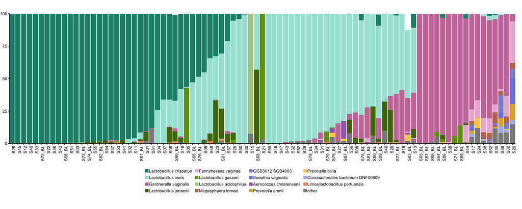

```r
#########################
# PRETTY PLOT ADDITIONS #
#########################
df_long_ <- df_long %>%
  # filter(sample == "S91_BL") %>%

  # assigne each sample into a taxa group (one of Lactobacillus, iners, Gardnerella or other )
  # gr.fun(.) # test
  mutate(gr = gr.fun(.)[as.character(.$sample)]) %>%
  mutate(gr_lvl = taxa_order.fun(.)) %>%

  # order samples by percentage of taxa within each level of "gr"
  # factor.fun(.) # test
  mutate(sample = factor(sample, levels = factor.fun(.))) %>%

  # fix taxa order:

  # Non-abundant taxa to "other":
  mutate(
    clade_name = ifelse(.$clade_name %in% n[1:15], .$clade_name, "other")
  ) %>%
  mutate(clade_name = factor(clade_name, levels = c(n[1:15], "other"))) %>%

  # gets colour for each taxa
  mutate(col = group.colors[as.character(.$clade_name)])


####################################################
# PLOT STRAIN LEVEL ABUNDANCE OF REMAINING SAMPLES #
####################################################
col_pal <- df_long_ %>% select(clade_name, col) %>% unique() %>% deframe()
colourCount <- length(unique(df_long_$clade_name))
getPalette <- colorRampPalette(brewer.pal(9, "Set1"))

#plot the ctrls
# quartz(width = 15, height = 6, dpi = 150)
barplot <- ggplot(
  df_long_,
  aes(x = sample, y = abundance, fill = clade_name) # round(value, digits = 3)
) +
  geom_col(width = .9, position = "stack") +
  # geom_text(aes(label = value), position = position_stack(vjust = 0.5)) +
  scale_fill_manual(values = col_pal) + # pal[1:colourCount]
  guides(
    fill = guide_legend(
      override.aes = list(size = 2),
      ncol = 4,
      byrow = FALSE,
      keyheight = .4,
      keywidth = .6
    )
  ) +
  theme_classic() +
  coord_cartesian(expand = F) +
  theme(
    plot.margin = unit(c(1, 0.5, 1, 0), "cm"),
    legend.spacing.y = unit(.5, 'cm'),
    legend.title = element_blank(),
    legend.text = element_text(margin = margin(r = .3, l = .3, unit = "pt"), ),
    axis.title = element_blank(),
    axis.text.x = element_text(angle = 90, hjust = 1),
    legend.position = "bottom"
  )

plot(barplot)
```

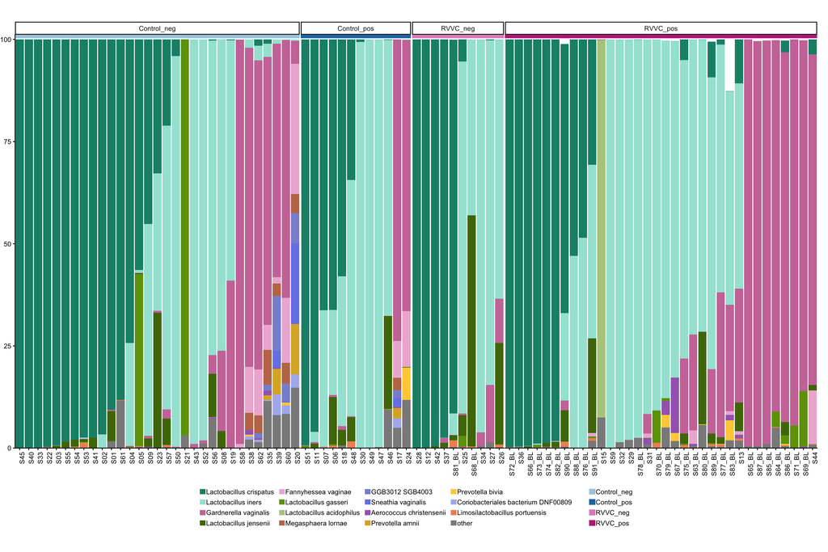

```r
library(ggnewscale)
####################################################
# PLOT GENUS LEVEL ABUNDANCE BY GROUPS #
####################################################
col_pal <- df_long_ %>% select(clade_name, col) %>% unique() %>% deframe()
colourCount <- length(unique(df_long_$clade_name))
getPalette <- colorRampPalette(brewer.pal(9, "Set1"))
lgd <- get_legend(barplot)

annot_bar <- df_long_ %>%
  left_join(., select(meta_gr, sample, RVVC_pos)) %>%
  #mutate(RVVC_pos = factor(RVVC_pos)) %>%
  mutate(sample_ = factor(sample, levels = factor.fun(.))) %>%
  arrange(RVVC_pos, sample_) %>%
  distinct(sample, RVVC_pos)
sample_order <- as.vector(annot_bar$sample)
#plot the ctrls
# quartz(width = 15, height = 6, dpi = 150)
barplot <- df_long_ %>%
  left_join(., select(meta_gr, sample, RVVC_pos), by = "sample") %>%
  mutate(sample = factor(sample, levels = sample_order)) %>%
  #mutate(sample = factor(sample, levels = annot_bar$sample)) %>%
  ggplot(
    .,
    aes(x = .data[["sample"]], y = abundance) # round(value, digits = 3)
  ) +

  # ---- Annotation bar at x = -0.5 ----
  geom_tile(
    aes(x = sample, y = 100.7, fill = RVVC_pos),
    inherit.aes = FALSE,
    height = 0.9, #
    #width = 0.9
  ) +
  scale_fill_manual(values = RVVC_pal) +
  guides(
    fill = guide_legend(
      override.aes = list(size = 2),
      ncol = 1,
      byrow = T,
      keyheight = .4,
      keywidth = .6
    )
  ) +
  new_scale_fill() +

  # ---- Main stacked bars ----
  geom_col(aes(fill = clade_name), width = .9, position = "stack") +
  # geom_text(aes(label = value), position = position_stack(vjust = 0.5)) +
  scale_fill_manual(values = col_pal) + # pal[1:colourCount]
  guides(
    fill = guide_legend(
      override.aes = list(size = 2),
      ncol = 4,
      byrow = FALSE,
      keyheight = .4,
      keywidth = .6
    )
  ) +
  theme_classic() +
  coord_cartesian(expand = F) +
  theme(
    plot.margin = unit(c(1, 0.5, 1, 0), "cm"),
    legend.spacing.y = unit(.5, 'cm'),
    legend.title = element_blank(),
    legend.text = element_text(
      margin = margin(r = .3, l = .3, unit = "pt"),
    ),
    axis.title = element_blank(),
    axis.text.x = element_text(angle = 90, hjust = 1),
    legend.position = "bottom"
  ) +
  # facet_wrap(~RVVC_pos, nrow = 1, scales = "free_x" ) +
  # space gives equal width of bars across facets:
  facet_grid(cols = vars(RVVC_pos), scales = "free_x", space = "free_x") +
  theme(panel.spacing.x = unit(0.1, "lines"), legend.position = "bottom")


plot(barplot)
```

```r
# panel_widths <- annot_bar %>% summarise(n_samples = n(), .by = "RVVC_pos")

# plot_grid(
#   plotlist = barplot,
#   nrow = 2,
#   align = "h",
#   rel_widths = c(31, 13, 30, 50)
# )

# plot(lgd)
```

## Step 6: Centered Log Ratio (CLR) Transformation

For technical, biological and computational reasons, microbiome data is compositional such that they represent proportions or relative information. Proportional data are restricted to a space where the sum of all OTU proportions for a given sample sums to 1. Using standard statistical methods on such data may lead to spurious results. Likewise, any data that are compositional in nature are interpreted into relative counts. Hence, using a CLR transformation allows the circumvention of these spurious results.

There are two ways of log-ratio transforming the data in mixOmics:

- Option 1: Some of our functions (pca, plsda) directly include the argument logratio = ‘CLR’, so all you need to do is include your filtered offset data and add this argument (see example below).
- Option 2: Some functions currently do not include the logratio argument. In this case, you will need to use the logratio.transfo() function as shown below. You can also use this function if you only have access to TSS (proportions) data and those were not offset.

unlike 16S data which are returned as raw counts after pre-processing, shotgun metageome data is often already normalized into proportions. This is because direct counts aren’t very meaningful across different taxa/genomes. That is why we will go with option 2 for our data.

information taken from: https://mixomics.org/mixmc/mixmc-preprocessing/

### Shotgun metagenomics

- You sequence **all DNA** in the sample, not just one marker gene.
- Reads are mapped to **reference genomes, genes, or functional categories**.
- Raw counts can be biased by factors like:
  - genome size
  - gene length
  - variable sequencing depth
- Because of this, many sequencing facilities preprocess shotgun data to produce **normalized relative abundances (proportions)**, so that samples can be compared more easily.

**Typical outputs include:**  
- Relative abundance (%) of taxa  
- RPKM / TPM / CPM for genes or functions

**NB!** the majority of mixOmics functions expect a format of samples as rows and features as columns, thus it is VERY important to first transpose the data when applying CLR!

```r
# Create matrix for all levels of taxa and transpose to samples (rows) x taxa (columns)
matrix <- data_filt_norm %>%
  #rename_with(~ str_replace(.x, "_BL$", ""), everything()) %>%
  nest(data = -level) %>%
  # filter(level == "strain") %>%
  mutate(
    data = map(
      data,
      ~ .x %>%
        column_to_rownames(var = "clade_name") %>%
        as.matrix() %>%
        t()
    )
  )

matrix
```

```
# A tibble: 8 × 2
  level   data
  <chr>   <list>
1 kingdom <dbl [87 × 2]>
2 phylum  <dbl [87 × 8]>
3 class   <dbl [87 × 13]>
4 order   <dbl [87 × 16]>
5 family  <dbl [87 × 21]>
6 genus   <dbl [87 × 32]>
7 species <dbl [87 × 51]>
8 strain  <dbl [87 × 57]>
```

```r
# Specify levels you want to process
tax_levels <- c("order", "family", "genus", "species", "strain")

matrix <- matrix %>%
  # Apply CLR transformation and PCA to each level
  mutate(
    # go from percent to proportion (sum to 1)
    data = map(data, ~ .x / 100),
    clr_data = map(
      data,
      ~ logratio.transfo(.x, logratio = "CLR", offset = 1e-6)
    )
  ) %>%
  mutate(across(2:3, ~ set_names(.x, paste0(.data[["level"]]))))

# check samples sum to 1 instead of 100
rowSums(matrix$data[[4]][1:3, ])
```

```
S01 S02 S03
  1   1   1
```

```r
matrix %>%
  select(1, data, clr_data) %>%
  saveRDS(
    .,
    "../Results/MixOmic/Metageonome_vagswab_CLR_transformed_1e-6.RDS"
  )
# matrix <- read_csv("../Results/MixOmic/Metageonome_vagswab_CLR_transformed.csv")
```

## Step 7: Exploratory Unsupervised PCA

```r
gr <- tibble(ID = colnames(data)[-c(1, 2)]) %>%
  #left_join(., gr_data, by = c("ID" = "svamp_ID"))
  left_join(., meta_gr, by = c("ID" = "sample"))

# gr <- tibble(sample = colnames(data)[-c(1, 2)]) %>%
#   left_join(., meta_gr, by = "sample")
```

```r
matrix <- matrix %>%
  # Filter matrix to only these levels
  filter(level %in% tax_levels) %>%

  # Apply CLR transformation and PCA to each level
  mutate(
    #clr_data = map(data, ~ logratio.transfo(.x, logratio = "CLR", offset = 1e-6)),
    pca_res = map(clr_data, ~ pca(.x)),
    plot = map2(
      pca_res,
      level,
      ~ plotIndiv(
        .x,
        col = pal$Clin_gr[1:length(unique(gr$Clin_gr))],
        group = gr$Clin_gr,
        ind.names = F,
        size.title = 9,
        title = paste0(.y)
      )
    ),
    plot2 = map2(
      pca_res,
      level,
      ~ plotIndiv(
        .x,
        col = pal$RVVC_pos[1:length(unique(gr$RVVC_pos))],
        group = gr$RVVC_pos,
        ind.names = F,
        size.title = 9,
        title = paste0(.y)
      )
    )
  ) %>%
  mutate(across(2:5, ~ set_names(.x, paste0(.data[["level"]]))))
```

```r
# Plot PCA for selected levels
l <- get_legend(
  plotIndiv(
    matrix$pca_res[["genus"]],
    col = pal$Clin_gr[1:length(unique(gr$Clin_gr))],
    legend = T,
    group = gr$Clin_gr
  )$graph
)
```

```r
l2 <- get_legend(
  plotIndiv(
    matrix$pca_res[["genus"]],
    col = pal$RVVC_pos[1:length(unique(gr$RVVC_pos))],
    legend = T,
    group = gr$RVVC_pos
  )$graph
)
```

```r
p <- matrix$plot %>% map("graph")
p2 <- matrix$plot2 %>% map("graph")
```

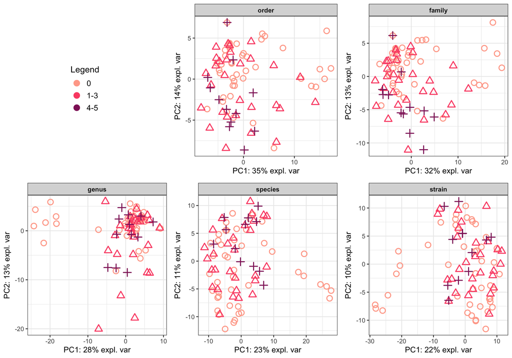

```r
plot_grid(
  plotlist = c(list(l), p),
  #labels = matrix$level,   # use taxonomy levels as labels
  ncol = 3
)
```

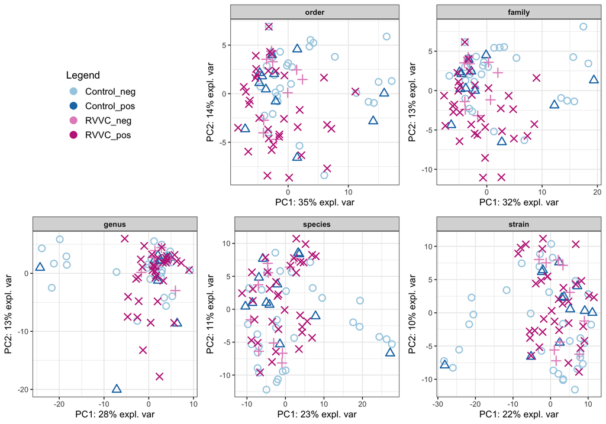

```r
plot_grid(
  plotlist = c(list(l2), p2),
  #labels = matrix$level,   # use taxonomy levels as labels
  ncol = 3
)
```

There are no clear seperation between the labels at any of the taxa levels. A google search indicate that Some studies find family or genus level is often most informative. Im wondering weather I can combine the matrix for genus and species level and to the PLS-DA on that?

Now that the data is:

- filtered for low abundant taxa
- CLR transformed
- offset added

Now we can move on to the Feature selection (PLS-DA) For this portion of the script we are following the MixOmics tutorial here: https://mixomics.org/mixmc/koren-bodysites-case-study/

## Step 8: Exploratory Heatmap

```r
library(ComplexHeatmap)
library(circlize)
# no need to scale or center abundance data as this inherently in percent:
# we only need to log transforme the data and add a off-set
# I dont know if it is more appropriate to use abundanc or CLR normalized data

# CLR
matrix.h <- matrix$clr_data$species %>% t()

# log abundance
# matrix.h <- matrix.h + 0.0001 %>% log2()

# Filter
matrix.h <- matrix.h[, gr$ID]

top <- sort(rowSums(t(matrix$data$species)), decreasing = T)[1:50]
matrix.h <- matrix.h[names(top), ]

dim(matrix.h)
```

```
[1] 50 87
```

```r
##############
# ANNOTATION #
##############
# colour pallets
blue <- brewer.pal(6, name = "Blues")
purple <- brewer.pal(6, name = "Purples")
reds <- brewer.pal(6, name = "Reds")

Red <- brewer.pal(6, name = "Reds") %>% c(., "gray")
pal1 <- c("#f26386", "#a4d984", "#fbbc52") %>% c(., "gray") # "#f588af", "#fd814e"
pal2 <- c("#2266ac", "#91c5de") %>% c(., "gray")
pal3 <- c("#9e8dec", "#902267", "#cc93cf", "#a5c97b", "#de9548") %>%
  c(., "gray") #"#abcb4b" "#63d3b4"


# group information
cols <- c(
  "Clin_gr",
  "RVVC_pos",
  "Clinical score (0-5)",
  "Fungal culture: C. albicans (y/n)"
) %>%
  set_names()
# use if there are NAs:
lvls <- map(cols, ~ c(sort(unique(gr[[.x]])), "na"))

annot_df <- gr %>%
  select(1, any_of(cols)) %>%
  mutate(across(2:ncol(.), ~ factor(.x))) %>%
  # when NAs are present:
  #mutate(across(all_of(cols), ~ factor(.x, levels = lvls[[cur_column()]]))) %>%
  column_to_rownames(var = "ID")

# order samples acording to matrix
annot_df <- annot_df[colnames(matrix.h), ]

ann_colors <- map(colnames(annot_df), function(val) {
  # Levels for this column
  levs <- levels(annot_df[[val]])

  # CASE 1: column exists in pal → use provided palette
  if (val %in% names(pal)) {
    colors <- pal[[val]]
    return(set_names(colors[1:length(levs)], levs))
  }
  # CASE 2: column not in pal → generate paired palette
  colors <- gg_color_hue(length(levs))
  set_names(colors, levs)
  # colors <- brewer.pal(length(levs), "Paired")
  # if (length(levs) == length(colors)) {
  #   set_names(colors, levs)
  # } else {
  #   set_names(colors[1:length(levs)], levs)
  # }
})
# Name the list by column names
ann_colors <- set_names(ann_colors, colnames(annot_df))

# check samples number
dim(matrix.h)
```

```
[1] 50 87
```

```r
dim(annot_df)
```

```
[1] 87  4
```

```r
# top annotation object:
top_annot <- columnAnnotation(
  df = annot_df,
  #show_legend = FALSE,
  show_annotation_name = T,
  annotation_name_gp = gpar(fontsize = 8),
  annotation_legend_param = list(
    grid_height = unit(.1, "mm"),
    grid_width = unit(2, "mm"),
    title = "",
    labels_gp = gpar(fontsize = 7),
    title_gp = gpar(fontsize = 8)
  ),
  simple_anno_size = unit(.3, "cm"),
  #gap = unit(1, "cm"),
  col = ann_colors
)
```

[figure not shown]

Figure 3: Histogram showing the distribution of CLR normalized matrix values

```r
################
# PLOT HEATMAP #
################
# colour mapping
breaks.fun <- function(min, max, n) {
  x <- seq(min, max, length.out = n)
  x[which(x == median(x))] <- 0
  round(x)
  return(x)
}

q <- quantile(matrix.h, probs = seq(0, 1, 0.1))
# to better know what values to use for the legend
# we use the quantile() function to get appropriate limits
# we plot the distribution of values
# Convert to a data frame for ggplot
df <- data.frame(value = as.vector(matrix.h))

# Basic ggplot histogram
p <- ggplot(df, aes(x = value)) +
  geom_histogram(fill = "skyblue", color = "skyblue") +
  #scale_x_continuous(breaks = scales::breaks_pretty(n = 20)) +
  #scale_y_continuous(labels = label_comma()) + # <-- commas
  labs(
    title = "Distribution of Matrix Values",
    x = "Matrix Values",
    y = "Count"
  ) +
  theme_minimal(base_size = 14)

# plot to better see the outlier values
p2 <- p + ylim(0, 10)
plot_grid(p, p2, ncol = 2)
```

```r
# set limits for colourpallet
RdBu <- c(
  "#364B9A",
  "#4A7BB7",
  "#6EA6CD",
  "#98CAE1",
  "#C2E4EF",
  "white",
  "#FEDA8B",
  "#FDB366",
  "#F67E4B",
  "#DD3D2D",
  "#A50026"
)

# using min and max from the matrix matrix can work, but is usualy influenced too much
# from the min and max values which tend to be outliers
# col <- colorRamp2(breaks.fun(min(matrix.h), max(matrix.h), 7), colorRampPalette(c(RdBu))(7))

# instead we use the historgram to determine the min and max values of the scale
# values larger than 5 are all mapped to dark red and values less than -5 are all mapped to dark blue.
# col <- colorRamp2(breaks.fun(q["25%"], -q["25%"], 7), colorRampPalette(c(RdBu))(7))
```

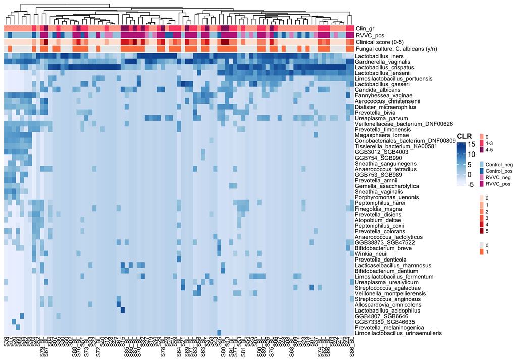

```r
################
# PLOT HEATMAP #
################
# Heatmap global options:
ht_opt$COLUMN_ANNO_PADDING <- unit(.05, "cm")
ht_opt$HEATMAP_LEGEND_PADDING <- unit(-0, "cm") #unit(c(0, 0, 0, -1), "cm") #b,l,t,r
ht_opt$TITLE_PADDING <- unit(.05, "cm")
ht_opt$DIMNAME_PADDING <- unit(.05, "cm")

# average expression:
H <- Heatmap(
  matrix.h,
  col = blue,
  cluster_columns = TRUE,
  show_row_dend = FALSE,
  name = "CLR",
  show_row_names = T,
  show_column_names = TRUE,
  column_names_gp = grid::gpar(fontsize = 8),
  row_names_gp = grid::gpar(fontsize = 8),

  # annotation
  # right_annotation = right_anno_row, left_annotation = left_anno_row,
  top_annotation = top_annot
)
H
```

```r
pdf(file = "./Heatmap_gene_expression.pdf", width = 10, height = 7)
H
dev.off()
```